# SARS CoV-2 mRNA vaccination exposes latent HIV to Nef-specific CD8+ T-cells

2022-March-15

# Samples

The following samples were part of this analysis:

| sample.ID | patient | condition | group |
| --- | --- | --- | --- |
| B032-1 | B032 | NoTx | NoTx |
| B032-2 | B032 | Pfizer1Per | Pfizer1Per |
| B032-4 | B032 | Moderna1per | Moderna1per |
| B032-6 | B032 | Flu2per | Flu2per |
| OM5011-1 | OM5011 | NoTx | NoTx |
| OM5011-2 | OM5011 | Pfizer1Per | Pfizer1Per |
| OM5011-4 | OM5011 | Moderna1per | Moderna1per |
| OM5011-6 | OM5011 | Flu2per | Flu2per |
| OM5334-1 | OM5334 | NoTx | NoTx |
| OM5334-2 | OM5334 | Pfizer1Per | Pfizer1Per |
| OM5334-4 | OM5334 | Moderna1per | Moderna1per |
| OM5334-6 | OM5334 | Flu2per | Flu2per |

# Principal component plot

Below is a PCA plot of all of the samples, colored by group, after adjusting for patient-specific effects with limma’s removeBatchEffect function.

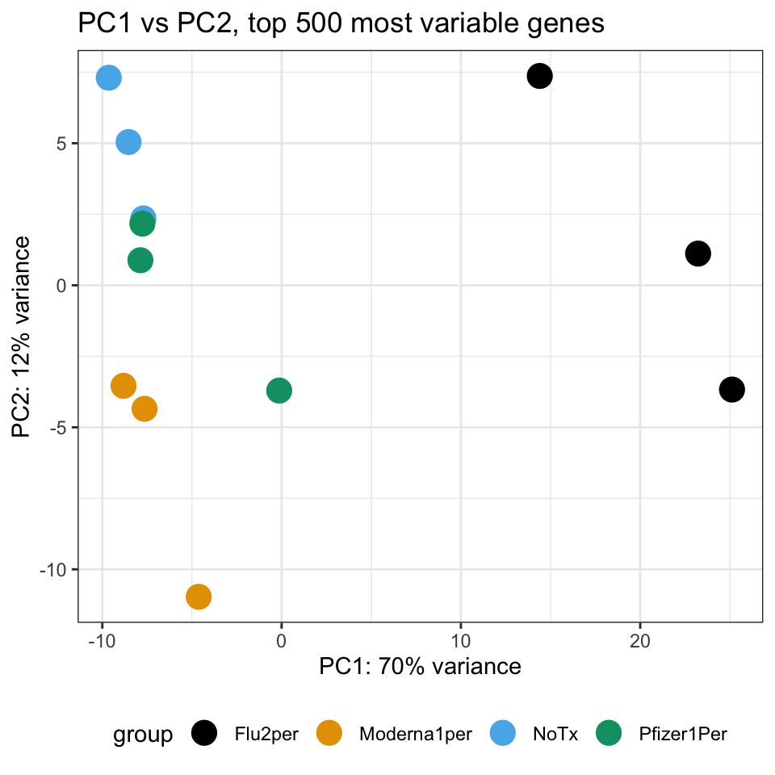

```r
coldata <- data.frame(decoder.data, row.names = colnames(counts), stringsAsFactors=F)
coldata$group <- factor(coldata$group)
dds <- DESeq2::DESeqDataSetFromMatrix(countData = counts,
                                      colData = coldata,
                                      design = ~patient+group)
dds <- estimateSizeFactors(dds)
vsd <- DESeq2::vst(dds, blind=TRUE)

design=model.matrix(~group, data=coldata)
assay(vsd) = limma::removeBatchEffect(assay(vsd), batch=coldata$patient, design=design)

data <- plotPCA(vsd, intgroup=c("group"), returnData=TRUE, ntop=500)
percentVar <- round(100 * attr(data, "percentVar"))

ggplot(data, aes(PC1, PC2, color=group)) +
  geom_point(size=5) +
  xlab(paste0("PC1: ",percentVar[1],"% variance")) +
  ylab(paste0("PC2: ",percentVar[2],"% variance")) +
  scale_color_colorblind() +
  theme_bw() + theme(legend.position="bottom") +
  ggtitle("PC1 vs PC2, top 500 most variable genes")
```

# DESeq

```r
coldata <- data.frame(decoder.data, row.names = colnames(counts), stringsAsFactors=F)
coldata$group <- factor(coldata$group)
dds <- DESeq2::DESeqDataSetFromMatrix(countData = counts,
                                      colData = coldata,
                                      design = ~patient+group)
keep <- rowSums(counts(dds)) >= 10
dds <- dds[keep,]
dds <- DESeq(dds)

vsd <- DESeq2::vst(dds, blind=TRUE)
design=model.matrix(~group, data=colData(dds))
normCounts = limma::removeBatchEffect(assay(vsd), batch=dds$patient, design=design)

baseMeanPerLvl <- sapply( levels(dds$group), function(lvl) rowMeans( counts(dds,normalized=TRUE)[,dds$group == lvl, drop=F] ) )

alphaTR = 0.05

Pfizer1Per_vs_NoTx <- results(dds, contrast=c("group","Pfizer1Per", "NoTx"), alpha=alphaTR)
Moderna1per_vs_NoTx <- results(dds, contrast=c("group","Moderna1per", "NoTx"), alpha=alphaTR)
Flu2per_vs_NoTx <- results(dds, contrast=c("group","Flu2per", "NoTx"), alpha=alphaTR)
```

Differential expression analysis was performed using DESeq2 with a two factor model: ~patient_groupd. Prior to differential expression analysis, we performed a minimal pre-filtering to keep only genes that have at least 10 reads total. The following genes were detected as differentially expressed (adjusted p < 0.05):

|  | padj<0.05 | contrast |
| --- | --- | --- |
| Pfizer1Per_vs_NoTx | 71 | 1 |
| Moderna1per_vs_NoTx | 193 | 2 |
| Flu2per_vs_NoTx | 3424 | 3 |

# Gene set enrichment with fgsea

GSEA typically needs to input data sets: 1. a **sorted list of genes**; 2. a collection of gene sets, e.g. specific **pathways**. The general approach entails that the GSEA tools will look for enrichments of genes that are at the top (or the bottom) of the gene list of interest with a given pathway, i.e., if the majority of genes that are part of pathway X are found at the top of the gene list, it is assumed that there is a positive correlation of whatever measure was used to sort the gene list with pathway X. We will be testing different sets of pathways originating from different sources: MSigDB Hallmark, MSigDB KEGG. We used the fgseaMultilevel function from the fgsea package with the following parameters were used: minGSSize = 15 ; maxGSSize = 500. Genes were ranked based on DESeq’s wald statistic (stat), which takes into account the log-fold change and its standard error (https://support.bioconductor.org/p/6124/).

## Pfizer

Pfizer1Per_vs_NoTx

|  | pathway | pval | padj | log2err | ES | NES | size | leadingEdge |
| --- | --- | --- | --- | --- | --- | --- | --- | --- |
| HALLMARK_INTERFERON_ALPHA_RESPONSE | HALLMARK_INTERFERON_ALPHA_RESPONSE | 1.000000e-10 | 2.500000e-09 | NA | 0.7114698 | 3.014395 | 95 | DHX58 , CCRL2 , RSAD2 , CMPK2 , TDRD7 , IFIT3 , RTP4 , NMI , IFIT2 , OAS1 , MX1 , IRF9 , LAMP3 , USP18 , CNP , IRF7 , OASL , IFI30 , CMTR1 , PARP12 , ADAR , PLSCR1 , SAMD9L , ISG15 , CASP8 , C1S , IFI… |
| HALLMARK_INTERFERON_GAMMA_RESPONSE | HALLMARK_INTERFERON_GAMMA_RESPONSE | 1.000000e-10 | 2.500000e-09 | NA | 0.5335933 | 2.474969 | 198 | TNFAIP3 , SOCS3 , NFKBIA , CD274 , DHX58 , IRF5 , SERPING1, SECTM1 , RSAD2 , IFIT1 , ARL4A , CMPK2 , TDRD7 , MVP , MYD88 , IFIT3 , XAF1 , RTP4 , NMI , IFIT2 , OAS3 , HIF1A , MX1 , IRF9 , USP18 , PELI1… |
| HALLMARK_TNFA_SIGNALING_VIA_NFKB | HALLMARK_TNFA_SIGNALING_VIA_NFKB | 3.445420e-10 | 5.742369e-09 | 0.8140358 | 0.4643196 | 2.154070 | 197 | LAMB3 , PLPP3 , BCL3 , PPP1R15A, BCL6 , SQSTM1 , DUSP1 , TNFAIP3 , SOCS3 , NFKBIA , KYNU , IER5 , EFNA1 , ZBTB10 , BIRC3 , LDLR , NINJ1 , ABCA1 , KLF6 , CSF2 , CEBPD , CCRL2 , STAT5A , PLAUR , NFKB2 ,… |
| HALLMARK_INFLAMMATORY_RESPONSE | HALLMARK_INFLAMMATORY_RESPONSE | 2.507878e-04 | 3.134848e-03 | 0.4984931 | 0.3554810 | 1.636124 | 180 | NFKBIA , ACVR1B , CCR7 , IL18RAP , LDLR , ABCA1 , KLF6 , CCRL2 , GNAI3 , C3AR1 , C5AR1 , IFNAR1 , MET , PLAUR , INHBA , RTP4 , NMI , HIF1A , LAMP3 , KIF1B , IRF7 , LPAR1 , P2RX7 , PVR , TNFAIP6 , RAF1… |
| KEGG_RIG_I_LIKE_RECEPTOR_SIGNALING_PATHWAY | KEGG_RIG_I_LIKE_RECEPTOR_SIGNALING_PATHWAY | 1.102807e-04 | 5.392185e-03 | 0.5384341 | 0.5165349 | 1.951333 | 54 | NFKBIA, MAPK12, DHX58 , OTUD5 , MAPK10, IRF7 , DDX3X , ISG15 , CASP8 , DDX58 , IFIH1 , CXCL8 , TANK , TRAF6 , TRIM25, AZI2 , FADD , IKBKB , MAPK14, MAPK13 |
| KEGG_TOLL_LIKE_RECEPTOR_SIGNALING_PATHWAY | KEGG_TOLL_LIKE_RECEPTOR_SIGNALING_PATHWAY | 1.299322e-04 | 5.392185e-03 | 0.5188481 | 0.4557132 | 1.873336 | 88 | NFKBIA, MAPK12, IRF5 , CTSK , IFNAR1, MYD88 , MAPK10, CCL3 , IRF7 , TLR5 , CCL4 , LY96 , CASP8 , CXCL8 , TRAF6 , TIRAP , TLR1 , AKT1 , JUN , PIK3R3, STAT1 , FADD , IKBKB , TOLLIP, TLR3 , MAPK14, PIK3C… |

### Heatmap of leading Edge of HALLMARK_TNFA_SIGNALING_VIA_NFKB (pfizer)

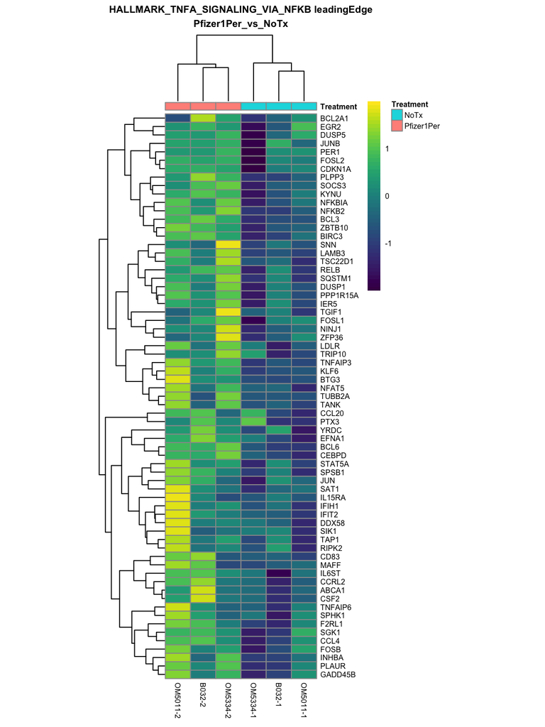

## Moderna

Moderna1per_vs_NoTx

|  | pathway | pval | padj | log2err | ES | NES | size | leadingEdge |
| --- | --- | --- | --- | --- | --- | --- | --- | --- |
| HALLMARK_INTERFERON_ALPHA_RESPONSE | HALLMARK_INTERFERON_ALPHA_RESPONSE | 0.0000000001 | 1.666667e-09 | NA | 0.5989961 | 2.566435 | 95 | UBA7 , DHX58 , IRF9 , PARP12 , IFI44 , C1S , RTP4 , CMTR1 , IFI44L , SLC25A28, CASP8 , CMPK2 , IRF7 , MOV10 , MX1 , TRIM25 , HELZ2 , HERC6 , RSAD2 , OAS1 , TDRD7 , ADAR , CASP1 , IFIT3 , CNP , PLSCR1 … |
| HALLMARK_INTERFERON_GAMMA_RESPONSE | HALLMARK_INTERFERON_GAMMA_RESPONSE | 0.0000941750 | 3.838062e-04 | 0.5384341 | 0.3477130 | 1.643880 | 198 | NOD1 , DHX58 , TNFAIP3 , IRF9 , PARP12 , XAF1 , CFH , MVP , IFI44 , CASP3 , C1S , RTP4 , CMTR1 , IFI44L , SLC25A28, NLRC5 , CASP8 , CMPK2 , IRF7 , MX1 , IRF5 , TRIM25 , IFIT1 , VCAM1 , HELZ2 , MYD88 ,… |
| KEGG_OTHER_GLYCAN_DEGRADATION | KEGG_OTHER_GLYCAN_DEGRADATION | 0.0010113265 | 7.994295e-03 | 0.4550599 | 0.6996024 | 1.947594 | 15 | MAN2C1, ENGASE, AGA , NEU3 , HEXA , MAN2B2 |
| KEGG_RIG_I_LIKE_RECEPTOR_SIGNALING_PATHWAY | KEGG_RIG_I_LIKE_RECEPTOR_SIGNALING_PATHWAY | 0.0015310596 | 1.105026e-02 | 0.4550599 | 0.4747449 | 1.802494 | 54 | DHX58 , IKBKB , MAPK10, OTUD5 , TKFC , IL12A , IRF3 , CASP8 , IRF7 , TRIM25, TRAF6 , ISG15 , RIPK1 , CASP10, MAPK11, DDX3Y , NFKBIA, IFIH1 , MAVS , MAPK8 , AZI2 , DDX58 , NLRX1 , MAPK12, TNF , SIKE1 ,… |